# Storm Events’ Impacts on US Health and Economy

## Data Processing

Data analysis is conducted based on the .csv data provided by NOAA.

```r
loaded_data <- read.csv("repdata_data_StormData.csv")
dim(loaded_data)
```

```
## [1] 902297     37
```

Since there are lots of values in EVTYPE that are actually same but mistakenly typed, we need to do some preprocessing before performing the analysis. Some errors include typos, unnecessary punctuation, lower/uppercase first alphabets, etc.

```r
# before preprocessing, number of unique events is
length(unique(loaded_data$EVTYPE))
```

```
## [1] 985
```

```r
# after preprocessing, number of unique events is
temp <- tolower(loaded_data$EVTYPE)
loaded_data$EVTYPE <- gsub("[[:punct:][:blank:]+]", " ", temp)
length(unique(loaded_data$EVTYPE))
```

```
## [1] 874
```

## 1. Most Harmful Events On Population

```r
unique_evtype <- unique(loaded_data$EVTYPE)

title <- c()
fat <- c()
inj <- c()
for (ev_name in unique_evtype) {
  title <- append(title, ev_name)
  fat <- append(fat, sum(loaded_data$FATALITIES[loaded_data$EVTYPE == ev_name]))
  inj <- append(inj, sum(loaded_data$INJURIES[loaded_data$EVTYPE == ev_name]))
}
# fatalities
df_fatalities <- data.frame(title, fat)
df_fatalities <- df_fatalities[order(df_fatalities$fat, decreasing=TRUE),]

# injuries
df_injuries <- data.frame(title, inj)
df_injuries <- df_injuries[order(df_injuries$inj, decreasing=TRUE),]
```

Top events that causes death

```r
head(df_fatalities, 15)
```

```
##                 title  fat
## 1             tornado 5633
## 98     excessive heat 1903
## 20        flash flood  978
## 27               heat  937
## 15          lightning  816
## 2           tstm wind  504
## 35              flood  470
## 18        rip current  368
## 45          high wind  248
## 72          avalanche  224
## 8        winter storm  206
## 432      rip currents  204
## 180         heat wave  172
## 42       extreme cold  162
## 16  thunderstorm wind  133
```

Top events that causes injuries

```r
head(df_injuries, 15)
```

```
##                 title   inj
## 1             tornado 91346
## 2           tstm wind  6957
## 35              flood  6789
## 98     excessive heat  6525
## 15          lightning  5230
## 27               heat  2100
## 64          ice storm  1975
## 20        flash flood  1777
## 16  thunderstorm wind  1488
## 3                hail  1361
## 8        winter storm  1321
## 862 hurricane typhoon  1275
## 45          high wind  1137
## 52         heavy snow  1021
## 217          wildfire   911
```

# Result

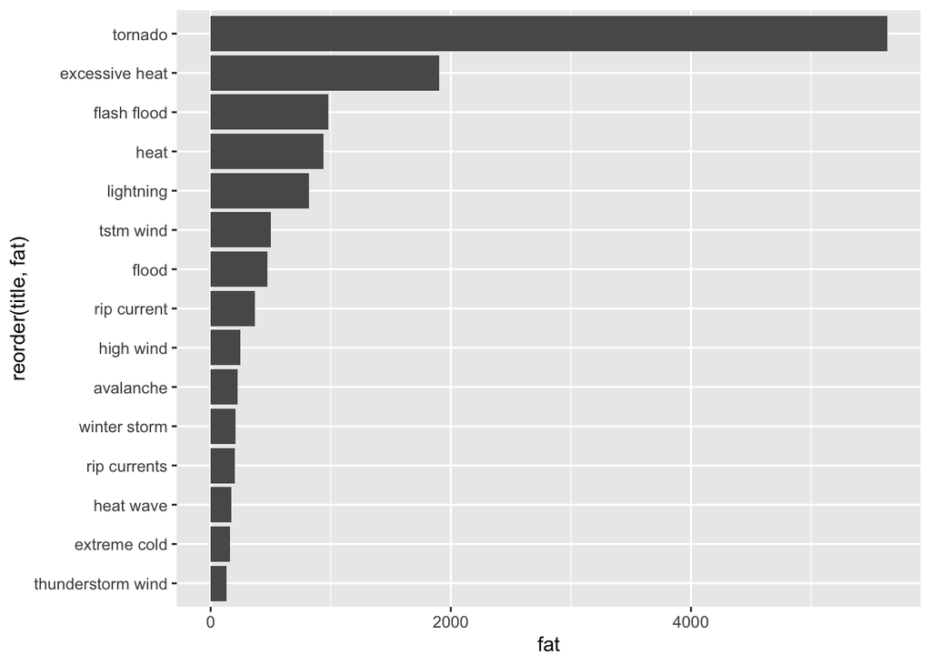

```r
library(ggplot2)
p1 <- ggplot(data=df_fatalities[1:15,], aes(x=fat, y=reorder(title, fat))) + geom_bar(stat="identity")
p1
```

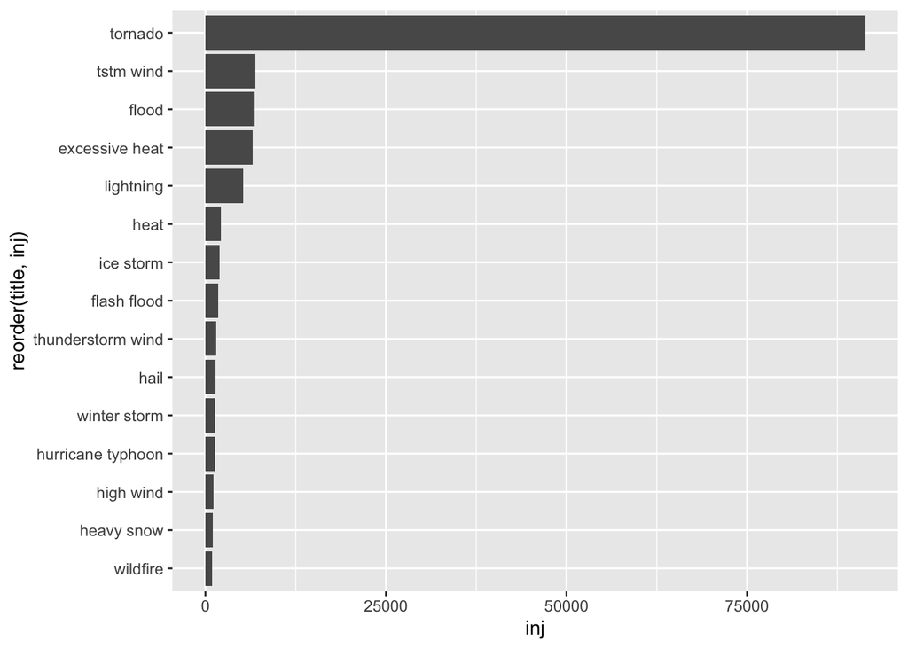

```r
p2 <- ggplot(data=df_injuries[1:15,], aes(x=inj, y=reorder(title, inj))) + geom_bar(stat="identity")
p2
```

Hence it can be concluded that tornado is main cause of deaths and injuries.

## 2. Most Harmful Event on Economy

We utilize property and crop damage to find the most harmful event on economy. First, we check unique data in **`PROPDMGEXP`** and **`CROPDMGEXP`**.

```r
unique(loaded_data$PROPDMGEXP)
```

```
##  [1] "K" "M" ""  "B" "m" "+" "0" "5" "6" "?" "4" "2" "3" "h" "7" "H" "-" "1" "8"
```

```r
unique(loaded_data$CROPDMGEXP)
```

```
## [1] ""  "M" "K" "m" "B" "?" "0" "k" "2"
```

We need to tweak the data a bit to make our work easier. Hence we need to change the convert the value according to its unit value.

```r
converter <- function(x) {
  if (x == 'h' | x == 'H')
    return(2)
  else if (x == 'k' | x == 'K')
    return(3)
  else if (x == 'm' | x == 'M')
    return(6)
  else if (x == 'b' | x == 'B')
    return(9)
  else if (!is.na(as.numeric(x)))
    return(as.numeric(x))
  else {0}
  }
```

Now, we convert the PROPDMG and CROPDMG values by multiplying them with their exponential values, then put them in temporary variables.

```r
temp <- sapply(loaded_data$PROPDMGEXP, FUN=converter)
prop_dmg <- loaded_data$PROPDMG * (10 ** temp)
temp <- sapply(loaded_data$CROPDMGEXP, FUN=converter)
crop_dmg <- loaded_data$CROPDMG * (10 ** temp)
```

Now, we try to calculate the sum of damages according to event names.

```r
df_prop_dmg <- data.frame("title" = loaded_data$EVTYPE, prop_dmg)
df_crop_dmg <- data.frame("title" = loaded_data$EVTYPE, crop_dmg)

title <- c()
ttt <- c()
sss <- c()
for (ev_name in unique_evtype) {
  title <- append(title, ev_name)
  ttt <- append(ttt, sum(df_prop_dmg$prop_dmg[df_prop_dmg$title == ev_name]))
  sss <- append(sss, sum(df_crop_dmg$crop_dmg[df_crop_dmg$title == ev_name]))
}

#remake
df_prop_dmg <- data.frame(title, ttt)
df_crop_dmg <- data.frame(title, sss)

df_prop_dmg <- df_prop_dmg[order(df_prop_dmg$ttt, decreasing=TRUE),]
df_crop_dmg <- df_crop_dmg[order(df_crop_dmg$sss, decreasing=TRUE),]
```

Top events that causes property damages

```r
head(df_prop_dmg, 15)
```

```
##                 title          ttt
## 35              flood 144657709807
## 862 hurricane typhoon  69305840000
## 1             tornado  56947380676
## 201       storm surge  43323536000
## 20        flash flood  16822673978
## 3                hail  15735267513
## 222         hurricane  11868319010
## 205    tropical storm   7703890550
## 8        winter storm   6688497251
## 45          high wind   5270046295
## 51        river flood   5118945500
## 217          wildfire   4765114000
## 865  storm surge tide   4641188000
## 2           tstm wind   4484958495
## 64          ice storm   3944927860
```

Top events that causes crop damages

```r
head(df_crop_dmg, 15)
```

```
##                 title         sss
## 192           drought 13972566000
## 35              flood  5661968450
## 51        river flood  5029459000
## 64          ice storm  5022113500
## 3                hail  3025954473
## 222         hurricane  2741910000
## 862 hurricane typhoon  2607872800
## 20        flash flood  1421317100
## 42       extreme cold  1312973000
## 366      frost freeze  1094186000
## 14         heavy rain   733399800
## 205    tropical storm   678346000
## 45          high wind   638571300
## 2           tstm wind   554007350
## 98     excessive heat   492402000
```

# Result

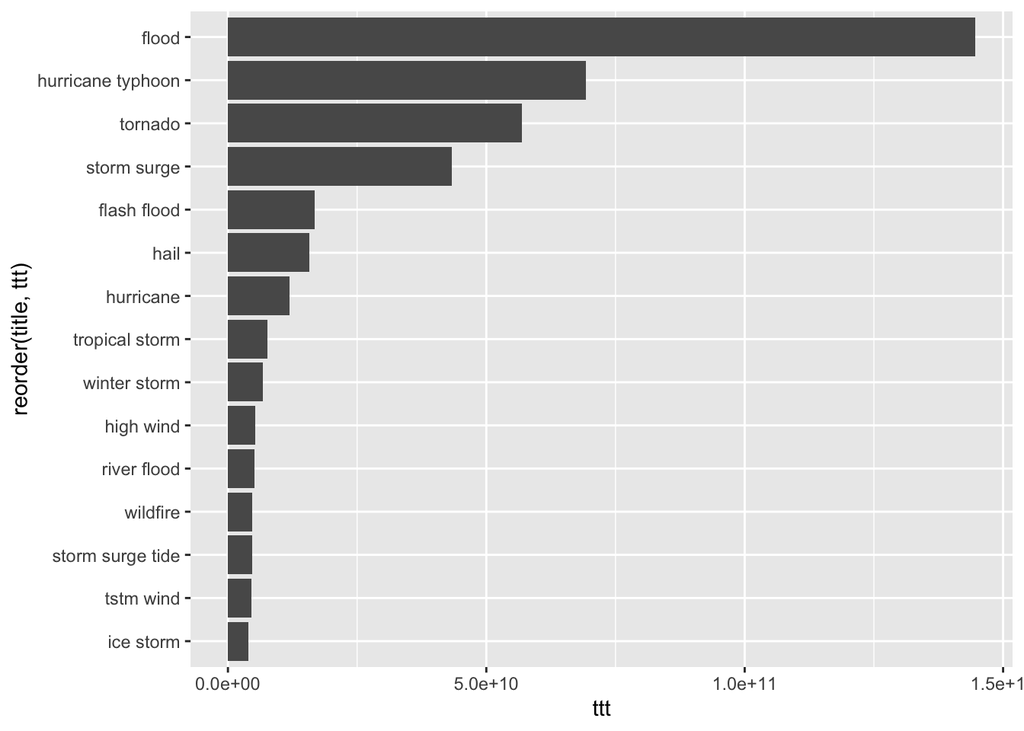

```r
library(ggplot2)
p1 <- ggplot(data=df_prop_dmg[1:15,], aes(x=ttt, y=reorder(title, ttt))) + geom_bar(stat="identity")
p1
```

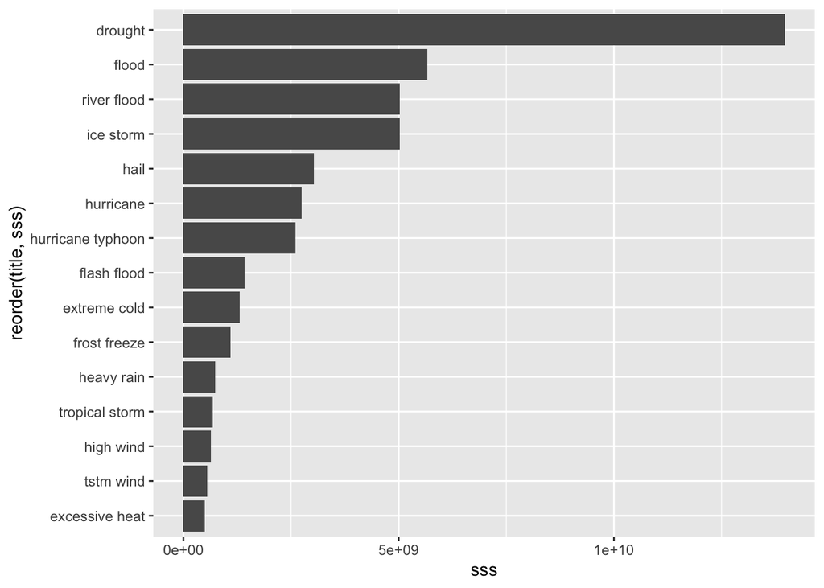

```r
p2 <- ggplot(data=df_crop_dmg[1:15,], aes(x=sss, y=reorder(title, sss))) + geom_bar(stat="identity")
p2
```

Hence it can be concluded that flood is main cause of property damages, and drought is the main cause of crop damages.